# BC2S3 NIL Introgression-Size Distribution

Author

Fausto Rodríguez-Zapata

Published

June 12, 2026

**Repo:** sawers-rellan-labs/zealtiger

## Setup

**Purpose**: Load packages, source stage functions, fix the seed.

**Approach**: Functions live in `R/01_compile_map.R` … `R/04_summarize.R` (see the spec). simcross 0.8 is already installed.

**Expected outcome**: A clean session with all helpers in scope.

```r
library(tidyverse)
library(simcross)
library(furrr)
library(patchwork)

# Stage functions (defined per the specification)
purrr::walk(fs::dir_ls("R", glob = "*.R"), source)

set.seed(params$seed)
plan(multisession)

map_dir <- params$map_dir

fs::dir_create("results/figures")

# Diagnostics
cat("simcross:", as.character(packageVersion("simcross")),
    "| seed:", params$seed,
    "| target NILs:", params$n_nil, "\n")
```

```
simcross: 0.8 | seed: 20260609 | target NILs: 1400
```

### Input data — MaizeGDB consensus map

The Stage-1 input is the ten MaizeGDB consensus genetic-map files (map ids 1203637–1203646) in `data/maizegdb_consensus_map/consensus_chr01.txt … consensus_chr10.txt`, fetched by `download_consensus_map.sh`. `data/` is git-ignored, so the chunk below **runs the download script automatically if the files are not already present** — making the notebook reproducible from a fresh clone.

Each `consensus_chrNN.txt` is a tab-separated MaizeGDB *map_text* export: line 1 is a free-text title (skipped), line 2 the header, then columns `Locus`, `Coordinate` (cM), `Bin`, followed by repeating 4-column blocks per assembly (`<assembly>_gene_model / _chr / _start / _end`). `parse_consensus_v5()` locates the **B73 NAM v5** block (`Zm-B73-REFERENCE-NAM-5.0_*`) *by name* — its column index differs between files — and keeps `Locus`, `Coordinate` (cM), and the v5 `chr / start / end`.

```r
# data/ is git-ignored: fetch the consensus map if it isn't already there.
chr_files <- fs::dir_ls(map_dir, glob = "*chr*.txt", fail = FALSE)
if (length(chr_files) < 10) {
  message("Consensus map missing in ", map_dir,
          " - running download_consensus_map.sh ...")
  stopifnot(system2("bash", "download_consensus_map.sh") == 0)
  chr_files <- fs::dir_ls(map_dir, glob = "*chr*.txt")
}
stopifnot(length(chr_files) == 10)
cat("Consensus-map files present:", length(chr_files), "in", map_dir, "\n")
```

```
Consensus-map files present: 10 in data/maizegdb_consensus_map
```

## Stage 1 — Compile the maize map (v5 NAM)

### 1.1 Parse consensus files

**Purpose**: Extract (locus, cM, chr, bp) anchors from all 10 chromosome files, using the B73 NAM v5 physical columns.

**Approach**: `parse_consensus_v5()` matches v5 columns by squished name (robust to per-file column differences), drops rows lacking physical coordinates, and sets `bp` to the v5 gene-model midpoint.

**Expected outcome**: One tidy tibble of raw anchors across chromosomes.

```r
map_files <- fs::dir_ls(map_dir, glob = "*chr*.txt")

anchors_raw <- map_files %>%
  purrr::map(parse_consensus_v5) %>%
  purrr::list_rbind() %>%
  dplyr::arrange(chr, bp)

# Diagnostics
cat("Files parsed:", length(map_files),
    "| raw anchors:", nrow(anchors_raw),
    "| chrs:", paste(sort(unique(anchors_raw$chr)), collapse = ","), "\n")
```

```
Files parsed: 10 | raw anchors: 20051 | chrs: 1,2,3,4,5,6,7,8,9,10
```

### 1.2 Enforce a monotone Marey map

**Purpose**: Remove map inversions (mismapped / paralogous loci) so cM is non-decreasing along the physical axis within each chromosome.

**Approach**: `enforce_monotone()` sorts by bp and applies a running-max filter on cM. Track how many anchors are dropped per chromosome — large losses flag consensus-vs-v5 disagreement (often pericentromeric).

**Expected outcome**: A monotone anchor set + a per-chr drop report.

```r
anchors_clean <- enforce_monotone(anchors_raw)
drop_report   <- report_map_qc(anchors_raw, anchors_clean)

saveRDS(anchors_clean, "results/maize_map_v5_clean.rds")

# Diagnostics
cat("Clean anchors:", nrow(anchors_clean),
    "| total dropped:", sum(drop_report$dropped), "\n")
```

```
Clean anchors: 19486 | total dropped: 565
```

```r
drop_report
```

| chr | n_raw | n_clean | cm_span | mb_span | dropped | pct_dropped | cm_per_mb |
| --- | --- | --- | --- | --- | --- | --- | --- |
| 1 | 3163 | 2986 | 285.80 | 308.2853 | 177 | 5.6 | 0.927 |
| 2 | 2413 | 2365 | 181.80 | 243.3856 | 48 | 2.0 | 0.747 |
| 3 | 2143 | 2075 | 208.35 | 237.5077 | 68 | 3.2 | 0.877 |
| 4 | 2060 | 2050 | 187.24 | 249.5008 | 10 | 0.5 | 0.750 |
| 5 | 2259 | 2228 | 170.90 | 225.9598 | 31 | 1.4 | 0.756 |
| 6 | 1682 | 1599 | 137.27 | 175.0009 | 83 | 4.9 | 0.784 |
| 7 | 1584 | 1476 | 156.01 | 185.6142 | 108 | 6.8 | 0.841 |
| 8 | 1798 | 1782 | 158.99 | 181.9956 | 16 | 0.9 | 0.874 |
| 9 | 1516 | 1499 | 160.17 | 161.0884 | 17 | 1.1 | 0.994 |
| 10 | 1433 | 1426 | 135.89 | 152.1537 | 7 | 0.5 | 0.893 |

### 1.3 Thin to the marker grid + per-chr cM lengths

**Purpose**: Build the ~2500-marker grid and the vector of per-chromosome cM lengths that `sim_from_pedigree` needs as `L`.

**Approach**: `thin_markers()` allocates the quota per chromosome in proportion to cM span and selects markers evenly in cM. `L` = max cM per chromosome from the clean map.

**Expected outcome**: `marker_grid` (for cM↔︎Mb + optional `convert2geno`) and `chr_cm_lengths` (the simulation input).

```r
marker_grid <- thin_markers(anchors_clean, n_target = params$n_markers)

chr_cm_lengths <- anchors_clean %>%
  dplyr::group_by(chr) %>%
  dplyr::summarise(L = max(cm), .groups = "drop") %>%
  dplyr::arrange(chr)

saveRDS(marker_grid, "results/maize_map_v5_grid2500.rds")

# Diagnostics
cat("Markers retained:", nrow(marker_grid),
    "(target", params$n_markers, "; cap, not a guarantee)",
    "| total map length (cM):", round(sum(chr_cm_lengths$L), 1), "\n")
```

```
Markers retained: 2296 (target 2500 ; cap, not a guarantee) | total map length (cM): 1783.2
```

```r
chr_cm_lengths
```

| chr | L |
| --- | --- |
| 1 | 285.80 |
| 2 | 181.80 |
| 3 | 208.40 |
| 4 | 187.27 |
| 5 | 171.00 |
| 6 | 137.77 |
| 7 | 156.02 |
| 8 | 159.00 |
| 9 | 160.17 |
| 10 | 135.99 |

### 1.4 Marey QC plot

**Purpose**: Visual gate before simulating — confirm the cleaned map is monotone and sensibly shaped per chromosome.

**Approach**: cM-vs-Mb scatter, clean anchors overlaid, faceted by chr.

**Expected outcome**: `results/marey_maps.pdf`. **Inspect before Stage 2.**

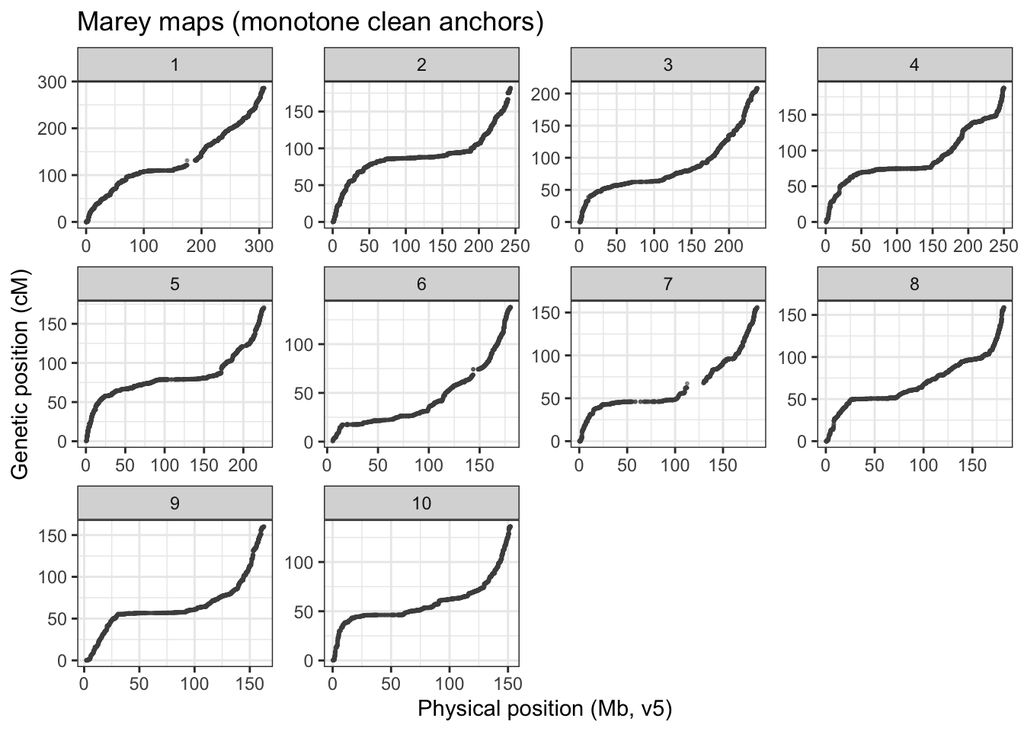

```r
marey <- anchors_clean %>%
  ggplot(aes(bp / 1e6, cm)) +
  geom_point(size = 0.4, alpha = 0.5, colour = "grey30") +
  facet_wrap(~ chr, scales = "free") +
  labs(x = "Physical position (Mb, v5)", y = "Genetic position (cM)",
       title = "Marey maps (monotone clean anchors)") +
  theme_bw()

ggsave("results/marey_maps.pdf", marey, width = 11, height = 8)
marey
```

## Stage 2 — Pedigree + simulation (no selection)

### 2.1 Build and validate the pedigree

**Purpose**: Define the BC2S3 NIL pedigree (final NIL = id 8).

**Approach**: `bc2s3_pedigree()`; validate with `check_pedigree()`. Selfing is encoded as `mom == dad`, so a single parent is both “mom” and “dad” — the default sex-consistency check cannot pass and we use `ignore_sex = TRUE`. Sex is immaterial for autosomal maize.

**Expected outcome**: `TRUE` from the check.

```r
ped <- bc2s3_pedigree()
stopifnot(check_pedigree(ped, ignore_sex = TRUE))

# Diagnostics
cat("Pedigree rows:", nrow(ped),
    "| founders:", sum(ped$mom == 0 & ped$dad == 0), "\n")
```

```
Pedigree rows: 8 | founders: 2
```

```r
ped
```

| id | mom | dad | sex | gen |
| --- | --- | --- | --- | --- |
| 1 | 0 | 0 | 0 | 0 |
| 2 | 0 | 0 | 1 | 0 |
| 3 | 1 | 2 | 0 | 1 |
| 4 | 1 | 3 | 1 | 2 |
| 5 | 1 | 4 | 0 | 3 |
| 6 | 5 | 5 | 1 | 4 |
| 7 | 6 | 6 | 0 | 5 |
| 8 | 7 | 7 | 1 | 6 |

### 2.2 Pilot run (n = 20) — fail fast

**Purpose**: Confirm allele labeling + donor dosage before scaling.

**Approach**: Simulate 20 NILs. The validation metric is **donor dosage** = donor cM summed over *both* haplotypes / (2 × total map cM); this is the allele frequency and converges to the analytical BC2S3 expectation **0.125**.

> Note: this dosage is distinct from the *unioned* introgression span used for the size distribution. A locus is “introgressed” if **either** haplotype is donor, so the union fraction (≈ f₂ + f₁ ≈ 0.141) is higher than the dosage (f₂ + ½f₁ = 0.125). We validate the dosage; we report sizes from the union.

**Expected outcome**: Mean donor dosage ≈ 0.125 (within MC error).

```r
total_cm <- sum(chr_cm_lengths$L)

sim_one <- function(i) {
  res <- simulate_nil(ped, chr_cm_lengths,
                      m = params$m_interference, p = params$p_escape,
                      donor_allele = params$donor_allele)
  res$segments$nil_id <- i
  res
}

pilot <- furrr::future_map(seq_len(20), sim_one,
                           .options = furrr_options(seed = TRUE))
pilot_dosage <- purrr::map_dbl(pilot, "donor_cm_hap") / (2 * total_cm)

# Diagnostics
cat("Pilot mean donor dosage:", round(mean(pilot_dosage), 4),
    "| expected: 0.1250\n")
```

```
Pilot mean donor dosage: 0.1349 | expected: 0.1250
```

```r
stopifnot(abs(mean(pilot_dosage) - 0.125) < 0.03)
```

### 2.3 Full simulation (n = 1400)

**Purpose**: Generate the full NIL set and collect donor segments in cM.

**Approach**: Parallel replicate simulation; tag each line with `nil_id`. Donor intervals are unioned across mat/pat per chromosome.

**Expected outcome**: `segments_cm` (one row per unioned donor segment) and `dosage_per_line` (the genome-wide validation).

```r
sims <- furrr::future_map(seq_len(params$n_nil), sim_one,
                          .options = furrr_options(seed = TRUE))

segments_cm     <- purrr::list_rbind(purrr::map(sims, "segments"))
dosage_per_line <- purrr::map_dbl(sims, "donor_cm_hap") / (2 * total_cm)

# Diagnostics
cat("NILs simulated:", dplyr::n_distinct(segments_cm$nil_id),
    "| total donor segments:", nrow(segments_cm),
    "| genome-wide mean dosage:", round(mean(dosage_per_line), 4),
    "(expect 0.1250)\n")
```

```
NILs simulated: 1400 | total donor segments: 14460 | genome-wide mean dosage: 0.1248 (expect 0.1250)
```

## Stage 3 — Convert segments cM → Mb

**Purpose**: Map donor cM intervals to physical Mb per chromosome.

**Approach**: `segments_to_mb()` builds a monotone `cM → bp` interpolator per chr from the full clean anchors (`make_cm_to_bp()`, linear, clamped) and applies it to each segment’s endpoints. We then assert no segment exceeds its chromosome’s physical length.

**Expected outcome**: `segments_mb` with `start_bp`, `end_bp`, `mb`.

```r
segments_mb <- segments_to_mb(
  dplyr::select(segments_cm, nil_id, chr, start_cm, end_cm), anchors_clean)

assert_within_chr_length(segments_mb, anchors_clean)

saveRDS(segments_mb, "results/nil_segments.rds")
readr::write_csv(segments_mb, "results/nil_segments.csv")

# Diagnostics
cat("Segments converted:", nrow(segments_mb),
    "| median segment (Mb):", round(median(segments_mb$mb), 2),
    "| max (Mb):", round(max(segments_mb$mb), 2), "\n")
```

```
Segments converted: 14460 | median segment (Mb): 10.71 | max (Mb): 243.96
```

## Stage 4 — Distribution + summaries

### 4.1 Per-NIL summary

**Purpose**: Collapse to one row per line (including lines with zero donor).

**Approach**: `summarise_nils()` — total donor Mb, segment count per NIL, filled to the full `n_nil` set so zero-introgression lines are represented.

**Expected outcome**: `nil_summary` + saved table.

```r
nil_summary <- summarise_nils(segments_mb, params$n_nil)

saveRDS(nil_summary, "results/nil_summary.rds")
readr::write_csv(nil_summary, "results/nil_summary.csv")

# Diagnostics
cat("Mean total donor Mb/line:", round(mean(nil_summary$total_mb), 1),
    "| mean segments/line:", round(mean(nil_summary$n_segments), 2),
    "| zero-donor lines:", sum(nil_summary$total_mb == 0), "\n")
```

```
Mean total donor Mb/line: 296.1 | mean segments/line: 10.33 | zero-donor lines: 0
```

### 4.2 Distribution figures

**Purpose**: Show the introgression-size distribution.

**Approach**: (a) total donor Mb per line, (b) per-segment Mb, (c) ECDF of segment Mb with median + 90th percentile annotated.

**Expected outcome**: Panels saved to `results/figures/`.

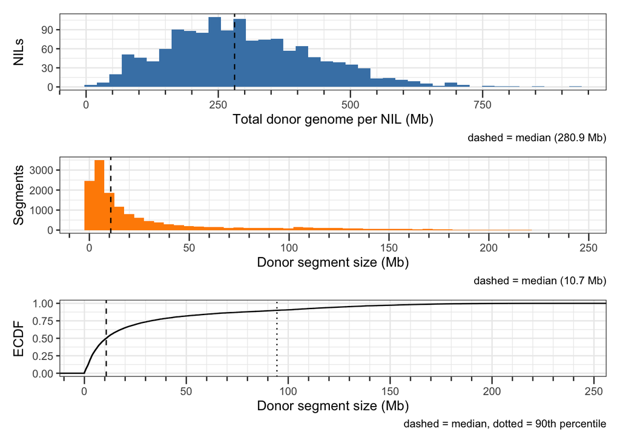

```r
med_total <- median(nil_summary$total_mb)
p_total <- ggplot(nil_summary, aes(total_mb)) +
  geom_histogram(bins = 40, fill = "steelblue") +
  geom_vline(xintercept = med_total, linetype = 2) +
  labs(x = "Total donor genome per NIL (Mb)", y = "NILs",
       caption = sprintf("dashed = median (%.1f Mb)", med_total)) +
  theme_bw()

med_seg <- median(segments_mb$mb)
p_seg <- ggplot(segments_mb, aes(mb)) +
  geom_histogram(bins = 50, fill = "darkorange") +
  geom_vline(xintercept = med_seg, linetype = 2) +
  labs(x = "Donor segment size (Mb)", y = "Segments",
       caption = sprintf("dashed = median (%.1f Mb)", med_seg)) +
  theme_bw()

q90 <- quantile(segments_mb$mb, 0.9)
p_ecdf <- ggplot(segments_mb, aes(mb)) +
  stat_ecdf() +
  geom_vline(xintercept = median(segments_mb$mb), linetype = 2) +
  geom_vline(xintercept = q90, linetype = 3) +
  labs(x = "Donor segment size (Mb)", y = "ECDF",
       caption = "dashed = median, dotted = 90th percentile") +
  theme_bw()

# minor x-axis ticks (ggplot2 >= 3.5): 10 Mb on the segment panels, 50 Mb on the
# total-genome panel (~900 Mb). The tick-length theme() is returned alongside the
# scale so it is applied AFTER theme_bw() (which otherwise resets tick lengths).
minor_ticks <- function(width)
  list(
    scale_x_continuous(minor_breaks = scales::breaks_width(width),
                       guide = guide_axis(minor.ticks = TRUE)),
    theme(axis.ticks.length.x       = unit(6, "pt"),
          axis.minor.ticks.length.x = unit(3.5, "pt"))
  )

dist_panel <- (p_total + minor_ticks(50)) /
              (p_seg   + minor_ticks(10)) /
              (p_ecdf  + minor_ticks(10))
ggsave("results/figures/introgression_size.pdf", dist_panel,
       width = 7, height = 10)
ggsave("results/figures/introgression_size.png", dist_panel,
       width = 7, height = 10, dpi = 150)
dist_panel
```

### 4.3 Interference sensitivity (m = 0 comparison)

**Purpose**: Bound how much positive interference shifts the segment-size tail (spec §8.2). The primary run uses simcross’s default `m = 10` (strong positive interference, biologically defensible for maize); here we re-run with `m = 0` (no interference) and compare.

**Approach**: A second full `n_nil` simulation at `m = 0, p = 0`; overlay the segment-size ECDFs and tabulate tail quantiles.

**Expected outcome**: `interference_comparison.csv` + an overlaid ECDF.

```r
sims_m0 <- furrr::future_map(
  seq_len(params$n_nil),
  function(i) {
    res <- simulate_nil(ped, chr_cm_lengths, m = 0, p = 0,
                        donor_allele = params$donor_allele)
    res$segments$nil_id <- i
    res
  },
  .options = furrr_options(seed = TRUE)
)
segments_m0 <- segments_to_mb(
  purrr::list_rbind(purrr::map(sims_m0, "segments")), anchors_clean)
dosage_m0 <- purrr::map_dbl(sims_m0, "donor_cm_hap") / (2 * total_cm)

cmp <- dplyr::bind_rows(
  dplyr::mutate(segments_mb, model = "default (m=10)"),
  dplyr::mutate(segments_m0, model = "no interference (m=0)")
)
cmp_summary <- cmp %>%
  dplyr::group_by(model) %>%
  dplyr::summarise(n_seg = dplyr::n(), median_mb = median(mb),
                   p90_mb = quantile(mb, 0.9), p99_mb = quantile(mb, 0.99),
                   max_mb = max(mb), .groups = "drop")
readr::write_csv(cmp_summary, "results/interference_comparison.csv")

p_cmp <- ggplot(cmp, aes(mb, colour = model)) +
  stat_ecdf() +
  labs(x = "Donor segment size (Mb)", y = "ECDF",
       title = "Interference sensitivity: segment-size tail", colour = NULL) +
  theme_bw() + theme(legend.position = "bottom")
ggsave("results/figures/interference_comparison.pdf", p_cmp, width = 7, height = 5)
ggsave("results/figures/interference_comparison.png", p_cmp, width = 7, height = 5,
       dpi = 150)

cmp_summary
```

| model | n_seg | median_mb | p90_mb | p99_mb | max_mb |
| --- | --- | --- | --- | --- | --- |
| default (m=10) | 14460 | 10.712772 | 94.45669 | 173.7743 | 243.9602 |
| no interference (m=0) | 14433 | 9.491701 | 94.69013 | 184.0026 | 295.5637 |

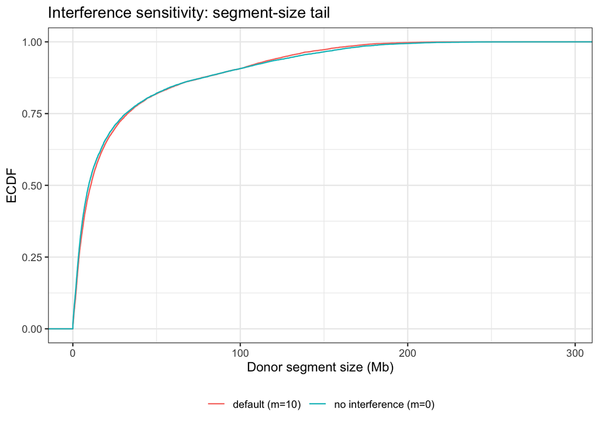

```r
p_cmp
```

### 4.4 Crossovers per genome — RTIGER `crossovers_per_megabase`

**Purpose**: Provide the detectable-crossover statistics needed to autotune the RTIGER rigidity parameter `r`. RTIGER segments the resequenced genome into donor/recurrent blocks; each block boundary is a detectable crossover. With two founders, every mosaic allele transition in the simulated NIL is exactly such a crossover, so we count `mat + pat` allele transitions per diploid genome.

**Approach**: `n_crossovers_hap()` (already applied inside `simulate_nil`, returned as `co_chr`) gives per-chromosome transition counts; `crossover_summary()` reduces them to per-genome and per-Mb statistics. RTIGER’s autotune wants the **highest** CO/Mb across samples as a conservative input, so we report both mean and max. The `m = 0` run bounds the value from above (no interference clusters fewer COs, lengthening the per-sample tail).

**Expected outcome**: per-genome CO mean/max, CO/Mb mean/max, per-chromosome CO counts, and the recommended `crossovers_per_megabase`.

```r
genome_mb <- sum(chr_phys_lengths(anchors_clean)$chr_mb)

co_genome <- tibble::tibble(
  nil_id = seq_along(sims),
  n_co   = purrr::map_dbl(sims, ~ sum(.x$co_chr$n_co))
)
co_stats <- crossover_summary(co_genome, genome_mb)

co_genome_m0 <- tibble::tibble(
  nil_id = seq_along(sims_m0),
  n_co   = purrr::map_dbl(sims_m0, ~ sum(.x$co_chr$n_co))
)
co_stats_m0 <- crossover_summary(co_genome_m0, genome_mb)

co_per_chr <- purrr::imap(sims, ~ dplyr::mutate(.x$co_chr, nil_id = .y)) %>%
  purrr::list_rbind() %>%
  dplyr::group_by(chr) %>%
  dplyr::summarise(mean_co = mean(n_co), max_co = max(n_co), .groups = "drop") %>%
  dplyr::left_join(chr_phys_lengths(anchors_clean), by = "chr") %>%
  dplyr::mutate(mean_co_per_mb = mean_co / chr_mb,
                max_co_per_mb  = max_co  / chr_mb)

# conservative per-chromosome CO/Mb vector (max over samples) for RTIGER
co_per_mb_vector <- setNames(co_per_chr$max_co_per_mb,
                             paste0("chr", co_per_chr$chr))

readr::write_csv(dplyr::mutate(co_genome, co_per_mb = n_co / genome_mb),
                 "results/nil_crossovers.csv")
readr::write_csv(co_per_chr, "results/crossovers_per_chr.csv")

# Diagnostics
cat(sprintf(
  "Detectable CO per genome (m=10): mean %.1f (sd %.1f), median %d, range %d-%d\n",
  co_stats$mean_co_genome, co_stats$sd_co_genome, co_stats$median_co_genome,
  co_stats$min_co_genome, co_stats$max_co_genome))
```

```
Detectable CO per genome (m=10): mean 33.3 (sd 9.0), median 33, range 8-62
```

```r
cat(sprintf("CO per Mb (m=10): mean %.4f | max (conservative) %.4f\n",
            co_stats$mean_co_per_mb, co_stats$max_co_per_mb))
```

```
CO per Mb (m=10): mean 0.0156 | max (conservative) 0.0291
```

```r
cat(sprintf("CO per Mb (m=0,  upper bound): mean %.4f | max %.4f\n",
            co_stats_m0$mean_co_per_mb, co_stats_m0$max_co_per_mb))
```

```
CO per Mb (m=0,  upper bound): mean 0.0157 | max 0.0362
```

```r
cat(sprintf("\n>>> RTIGER crossovers_per_megabase (genome-wide, conservative): %.4f <<<\n",
            co_stats$max_co_per_mb))
```

```
>>> RTIGER crossovers_per_megabase (genome-wide, conservative): 0.0291 <<<
```

```r
cat("\nPer-chromosome conservative CO/Mb vector (max over samples):\n")
```

```
Per-chromosome conservative CO/Mb vector (max over samples):
```

```r
print(round(co_per_mb_vector, 4))
```

```
  chr1   chr2   chr3   chr4   chr5   chr6   chr7   chr8   chr9  chr10
0.0714 0.0657 0.0589 0.0560 0.0530 0.0665 0.0754 0.0768 0.0737 0.0788
```

```r
co_per_chr
```

| chr | mean_co | max_co | chr_mb | mean_co_per_mb | max_co_per_mb |
| --- | --- | --- | --- | --- | --- |
| 1 | 5.245714 | 22 | 308.3227 | 0.01701371 | 0.07135381 |
| 2 | 3.445714 | 16 | 243.4841 | 0.01415170 | 0.06571270 |
| 3 | 3.830000 | 14 | 237.7613 | 0.01610859 | 0.05888259 |
| 4 | 3.487143 | 14 | 250.0601 | 0.01394522 | 0.05598655 |
| 5 | 3.219286 | 12 | 226.2472 | 0.01422907 | 0.05303934 |
| 6 | 2.635714 | 12 | 180.5340 | 0.01459955 | 0.06646948 |
| 7 | 2.927143 | 14 | 185.7962 | 0.01575459 | 0.07535138 |
| 8 | 2.958571 | 14 | 182.2607 | 0.01623264 | 0.07681307 |
| 9 | 3.038571 | 12 | 162.8858 | 0.01865461 | 0.07367123 |
| 10 | 2.477857 | 12 | 152.2861 | 0.01627107 | 0.07879906 |

### 4.5 Run metadata

**Purpose**: Record parameters for reproducibility.

**Approach**: Write params + versions to JSON, including both interference runs and the crossover statistics.

**Expected outcome**: `results/run_metadata.json`.

```r
jsonlite::write_json(
  list(
    seed        = params$seed,
    n_nil       = params$n_nil,
    n_markers   = nrow(marker_grid),
    total_cM    = total_cm,
    genome_Mb   = genome_mb,
    simcross    = as.character(packageVersion("simcross")),
    primary     = list(m = params$m_interference, p = params$p_escape,
                       mean_donor_dosage = mean(dosage_per_line),
                       mean_total_mb = mean(nil_summary$total_mb),
                       mean_co_per_genome = co_stats$mean_co_genome,
                       max_co_per_genome  = co_stats$max_co_genome,
                       mean_co_per_mb     = co_stats$mean_co_per_mb,
                       max_co_per_mb      = co_stats$max_co_per_mb),
    sensitivity = list(m = 0, p = 0,
                       mean_donor_dosage = mean(dosage_m0),
                       mean_total_mb = sum(segments_m0$mb) / params$n_nil,
                       max_co_per_mb = co_stats_m0$max_co_per_mb),
    rtiger_crossovers_per_megabase = co_stats$max_co_per_mb,
    date        = as.character(Sys.time())
  ),
  "results/run_metadata.json", pretty = TRUE, auto_unbox = TRUE
)
```

## Benchmarking RTIGER

**Purpose**: use the simulated NILs as ground truth to benchmark RTIGER’s ancestry/segment calling at the real **SNP50K** regime (λ ≈ 0.43×, ~71% missing).

**Approach**: `make_rtiger_benchmark.R` writes 100 NILs as RTIGER allele-count files with known truth; `fit_rtiger.R` fits RTIGER (Julia backend, fork `faustovrz/RTIGER@optimize-julia-core`) at a fixed rigidity; `score_rtiger.R` scores the calls against truth. We report **two rigidities** so the choice is not ad hoc:

- **r = 3** — the *minimum-CO-bias* point of the rigidity sweep (`docs/09`): of all rigidities tested it recovers the most crossovers. Reproduce with `Rscript fit_rtiger.R 0 3 0 4` then `Rscript score_rtiger.R --rtiger results/rtiger_benchmark/rtiger_out_r3/rtiger_result.rds`.
- **r = 8** — chosen *objectively* by RTIGER’s autotune (`optimize_R`, initial r₀ = 50, minimizing the expected number of erroneous segments). This is the **same value both empirical platforms** — MolBreeding 45K array and SNP50K skim — autotune to (`array_vs_skim.qmd`), so the simulation, the array, and the skim all agree on r = 8. Reproduce with `Rscript agent/autotune_rtiger_benchmark.R 0 50 "" 4` (writes `rtiger_out_auto/`, records the pick in `autotune_selected.txt`).

The trailing `4` is the Julia EM thread count: `threads = 4` cuts benchmark walltime **~35%** on this machine versus single-threaded; fits are deterministic in the thread count, so the tables below are identical regardless.

```r
library(RTIGER); library(readr)
setupJulia(JULIA_HOME = Sys.getenv("JULIA_HOME")); sourceJulia()

ed   <- read_csv("results/rtiger_benchmark/expDesign.csv",  show_col_types = FALSE)
sl   <- read_csv("results/rtiger_benchmark/seqlengths.csv", show_col_types = FALSE)
seqv <- setNames(sl$len, sl$chr_label)

# autotune=TRUE: fit once at the initial r0, run optimize_R (minimize the expected
# number of erroneous segments over a log-spaced rigidity grid), then refit at the
# winner. BOTH EM fits honour `threads`; optimize_R itself is analytic (single-thread).
# average_coverage and crossovers_per_megabase are left NULL so they are derived from
# the data — the same objective basis used on the real platforms (no truth peeking).
fit <- RTIGER(
  expDesign    = ed,
  outputdir    = "results/rtiger_benchmark/rtiger_out_auto",
  seqlengths   = seqv,
  rigidity     = 50L,        # initial r0
  autotune     = TRUE,
  max_rigidity = 2L^9L,
  save.results = FALSE,
  threads      = 4L,
  verbose      = TRUE
)
fit@params$rigidity   # -> 8  (autotuned rigidity; ~36 s / 100 NILs single-threaded)
```

**Expected outcome**: precision/recall by genotype class at both rigidities — the hand-tuned minimum-bias r = 3 and the objective autotune r = 8.

Marker-level per-state recall/precision. Overall accuracy 0.999, ~0.36% uncovered at both r.

| r | state | recall | precision |
| --- | --- | --- | --- |
| 3 | 0 homozygous recurrent | 1.000 | 0.999 |
| 3 | 1 heterozygous | 0.974 | 0.990 |
| 3 | 2 homozygous donor | 0.998 | 0.997 |
| 8 | 0 homozygous recurrent | 1.000 | 0.999 |
| 8 | 1 heterozygous | 0.974 | 0.983 |
| 8 | 2 homozygous donor | 0.996 | 0.997 |

Segment-level, reciprocal overlap >= 0.5, by rigidity.

| r | class | n_truth | precision | recall | F1 | FDR | boundary_kb |
| --- | --- | --- | --- | --- | --- | --- | --- |
| 3 | homozygous donor | 884 | 0.987 | 0.920 | 0.952 | 0.013 | 85 |
| 3 | heterozygous | 516 | 0.962 | 0.775 | 0.858 | 0.039 | 127 |
| 3 | TOTAL (donor present) | 1400 | 0.981 | 0.869 | 0.921 | 0.019 | 85 |
| 8 | homozygous donor | 884 | 0.999 | 0.887 | 0.939 | 0.001 | 85 |
| 8 | heterozygous | 516 | 0.895 | 0.773 | 0.830 | 0.105 | 127 |
| 8 | TOTAL (donor present) | 1400 | 0.980 | 0.861 | 0.917 | 0.020 | 85 |

Crossovers per genome vs ground truth (true = 21.8). r = 3 is the minimum-bias rigidity; the ~-2.4 floor is structural.

| r | called | true | co_bias |
| --- | --- | --- | --- |
| 3 | 19.4 | 21.8 | -2.44 |
| 8 | 19.1 | 21.8 | -2.71 |

**Takeaways**: marker-level genotyping is near-perfect (**99.9%**) at both rigidities; donor-segment **precision ≥ 0.98 (FDR ≤ 2%)** — almost no false introgressions; **recall ~0.86–0.92**, the missing ~8–14% being sub-Mb segments below the SNP50K detection floor (`docs/09`), not a tuning shortfall. Boundaries land within ~2 marker spacings (~85 kb; ~127 kb for het).

The two rigidities trade off as expected. **r = 3 minimizes crossover bias** (−2.4 vs −2.7) and gives the best heterozygous-segment precision (0.96 vs 0.90), so it recovers the most recombination — but no rigidity reaches zero bias, because the ~2.4-CO deficit is the structural sub-Mb floor at λ≈0.43×, not a tuning choice. **r = 8 is the objective autotune pick** and agrees with both empirical platforms, trading a slightly higher CO under-count for marginally cleaner homozygous-donor calls (precision 0.999, FDR 0.1%). RTIGER ran on the **fast path** (`save.results = FALSE`, ~30 s / 100 samples single-threaded, ~20 s at `threads = 4`) and was scored from the saved object.

## Production fit — real SNP50K population (per taxon)

The benchmark above is **100 *simulated* NILs** with known truth — it validates the caller, it is *not* the population call set. The production fit (**Source 2**) runs the same r = 8 RTIGER on the **real SNP50K skim**, grouped **by teosinte taxon** rather than jointly: samples within a taxon share divergence from B73, so pooling the HMM emission parameters is valid and gains power, while the largest group (Zx, 575) stays well under a single ~1,400-sample joint EM (`fit_rtiger_by_taxa.R`; calls in `data/rtiger_50K/calls_taxa_r8.csv`). After coverage QC (drop libraries with any chromosome under 2·r covered markers) the fit covers **1,391 samples across five taxa**:

RTIGER production fit on the real SNP50K population, r = 8, per teosinte taxon. Species from donor_id prefix -> founder_group in sample_metatada.csv. Wall seconds single-machine, threads = 4. 1,391 samples total.

| taxon | species | n | seconds | status |
| --- | --- | --- | --- | --- |
| Zx | Zea mays ssp. mexicana | 575 | 105.7 | ok |
| Zv | Zea mays ssp. parviglumis | 382 | 68.6 | ok |
| Zd | Zea diploperennis | 253 | 38.7 | ok |
| Zl | Zea luxurians | 120 | 25.7 | ok |
| Zh | Zea mays ssp. huehuetenangensis | 61 | 8.7 | ok |
| TOTAL | — | 1391 | 247.4 | — |